# Junpeng Jiang 2020 Bootcamp Submission

```r
library(dplyr)
```

```r
library(ggplot2)
```

# Task 1

```r
school <- read.csv(here::here("data/nys_schools.csv"))
acs <- read.csv(here::here("data/nys_acs.csv"))
```

# Task 2

```r
str(school)
```

```
## 'data.frame':    35663 obs. of  12 variables:
##  $ school_cd        : num  1.01e+10 1.01e+10 1.01e+10 1.01e+10 1.01e+10 ...
##  $ school_name      : chr  "MONTESSORI MAGNET SCHOOL" "MONTESSORI MAGNET SCHOOL" "MONTESSORI MAGNET SCHOOL" "MONTESSORI MAGNET SCHOOL" ...
##  $ district_name    : chr  "ALBANY CITY SCHOOL DISTRICT" "ALBANY CITY SCHOOL DISTRICT" "ALBANY CITY SCHOOL DISTRICT" "ALBANY CITY SCHOOL DISTRICT" ...
##  $ county_name      : chr  "ALBANY" "ALBANY" "ALBANY" "ALBANY" ...
##  $ region           : chr  "CAPITAL DISTRICT" "CAPITAL DISTRICT" "CAPITAL DISTRICT" "CAPITAL DISTRICT" ...
##  $ year             : int  2008 2009 2010 2011 2012 2013 2014 2015 2016 2017 ...
##  $ total_enroll     : num  316 312 300 326 294 321 335 347 366 359 ...
##  $ per_free_lunch   : num  0.33 0.32 0.26 0.22 0.31 0.25 0.35 0.22 0.29 0.26 ...
##  $ per_reduced_lunch: num  0.1 0.08 0.08 0.07 0.06 0.08 0.04 0 0.02 0.01 ...
##  $ per_lep          : num  0.01 0.02 0.03 0.03 0.03 0.03 0.06 0.06 0.05 0.07 ...
##  $ mean_ela_score   : num  658 673 670 667 670 ...
##  $ mean_math_score  : num  670 679 683 681 687 ...
```

```r
str(acs)
```

```
## 'data.frame':    496 obs. of  5 variables:
##  $ county_name            : chr  "ALBANY" "ALBANY" "ALBANY" "ALBANY" ...
##  $ year                   : int  2009 2010 2011 2012 2013 2014 2015 2016 2009 2010 ...
##  $ county_per_poverty     : num  0.118 0.119 0.121 0.124 0.123 ...
##  $ median_household_income: int  55350 56090 57715 59359 59394 59940 59887 60904 40917 41305 ...
##  $ county_per_bach        : num  0.19 0.197 0.199 0.198 0.205 ...
```

```r
summary(school)
```

```
##    school_cd         school_name        district_name      county_name
##  Min.   :1.010e+10   Length:35663       Length:35663       Length:35663
##  1st Qu.:2.802e+11   Class :character   Class :character   Class :character
##  Median :3.317e+11   Mode  :character   Mode  :character   Mode  :character
##  Mean   :3.568e+11
##  3rd Qu.:4.725e+11
##  Max.   :6.808e+11
##     region               year       total_enroll    per_free_lunch
##  Length:35663       Min.   :2008   Min.   : -99.0   Min.   :-99.0000
##  Class :character   1st Qu.:2010   1st Qu.: 339.0   1st Qu.:  0.1900
##  Mode  :character   Median :2013   Median : 469.0   Median :  0.4200
##                     Mean   :2013   Mean   : 523.6   Mean   :  0.4188
##                     3rd Qu.:2015   3rd Qu.: 648.0   3rd Qu.:  0.7200
##                     Max.   :2017   Max.   :2347.0   Max.   :257.0000
##  per_reduced_lunch      per_lep          mean_ela_score  mean_math_score
##  Min.   :-99.00000   Min.   :-99.00000   Min.   :-99.0   Min.   :-99.0
##  1st Qu.:  0.03000   1st Qu.:  0.00000   1st Qu.:296.0   1st Qu.:298.0
##  Median :  0.06000   Median :  0.03000   Median :324.2   Median :330.8
##  Mean   :  0.02852   Mean   :  0.04124   Mean   :447.1   Mean   :456.0
##  3rd Qu.:  0.10000   3rd Qu.:  0.11000   3rd Qu.:666.3   3rd Qu.:683.5
##  Max.   : 53.00000   Max.   :  1.00000   Max.   :720.8   Max.   :738.7
```

```r
summary(acs)
```

```
##  county_name             year      county_per_poverty median_household_income
##  Length:496         Min.   :2009   Min.   :0.04689    Min.   : 33794
##  Class :character   1st Qu.:2011   1st Qu.:0.10903    1st Qu.: 46347
##  Mode  :character   Median :2012   Median :0.12884    Median : 50135
##                     Mean   :2012   Mean   :0.13085    Mean   : 54116
##                     3rd Qu.:2014   3rd Qu.:0.14929    3rd Qu.: 56448
##                     Max.   :2016   Max.   :0.29935    Max.   :102044
##  county_per_bach
##  Min.   :0.07574
##  1st Qu.:0.11018
##  Median :0.13169
##  Mean   :0.14410
##  3rd Qu.:0.17431
##  Max.   :0.31795
```

- Check for data types
- There missing values in school dataset are labeled as -99, all categorical variables (plus school_cd) are complete.

# Task 3

### Dealing with Missing values

- Deal with -99, first count how many missing values there are.

```r
num_of_na <- rep(NA,6)
for (i in 7:12) {
  num_of_na[i-6] <- sum(school[,i] == -99)
}
num_of_na
```

```
## [1]   13   15   15   13 2208 2210
```

```r
dim(school)
```

```
## [1] 35663    12
```

- Remember that there are 35663 rows in the school dataset, so taking out 2200 rows should not affect the entire dataset considerably.

```r
new_school <- school
new_school[new_school == -99] <- NA
new_school <- na.omit(new_school)
dim(new_school)
```

```
## [1] 33437    12
```

- This way we take out all rows with missing values, and the remaining dataset new_school has 33437 observations.

### Create poverty level.

```r
county_avg_median <- acs %>%
  group_by(county_name) %>%
  summarise(n = mean(median_household_income))
```

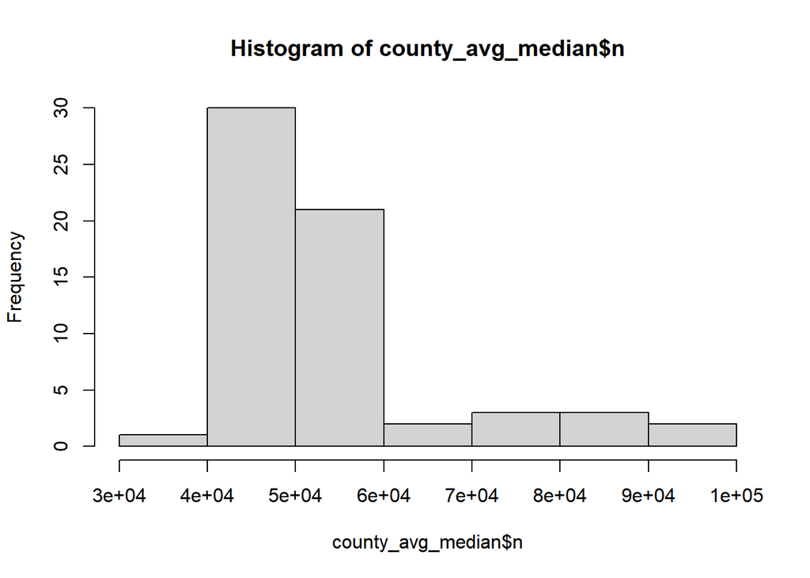

```r
county_avg_median <- as.data.frame(county_avg_median)
hist(county_avg_median$n)
```

- Compute average median income of each county across the years and plot a hisgram of the averages.

```r
summary(county_avg_median$n)
```

```
##    Min. 1st Qu.  Median    Mean 3rd Qu.    Max.
##   34422   46731   50069   54116   56768   97067
```

- By looking at the quantiles, I decide to split the groups as follows:
- < 46731 : low
- between 46731 and 56768: medium
- larger than 56768:high

```r
county_avg_median$group <- rep(NA,dim(county_avg_median)[1])
for (i in 1:dim(county_avg_median)[1]) {
  if(county_avg_median[i,'n'] < 46731){
      county_avg_median[i,'group'] <- "low"
  } else if(county_avg_median[i,'n'] >= 46731 && county_avg_median[i,'n'] <= 56768){
    county_avg_median[i,'group'] <- "medium"
  } else if(county_avg_median[i,'n'] > 56768){
    county_avg_median[i,'group'] <- "high"
  }
}
head(county_avg_median)
```

```
##   county_name        n  group
## 1      ALBANY 58579.88   high
## 2    ALLEGANY 42281.12    low
## 3       BRONX 34421.88    low
## 4      BROOME 45716.25    low
## 5 CATTARAUGUS 42811.88    low
## 6      CAYUGA 50686.00 medium
```

- This dataframe indexes each county with a group of low/medium/high.
- Then append the group variable back to the county dataset.

```r
acs$group <- rep(NA,dim(acs)[1])

for (i in 1:dim(acs)[1]) {
  rnum <- which(acs$county_name[i] == county_avg_median$county_name)
  acs[i,"group"] <- county_avg_median[rnum,"group"]
}
head(acs,15)
```

```
##    county_name year county_per_poverty median_household_income county_per_bach
## 1       ALBANY 2009          0.1183511                   55350      0.19036819
## 2       ALBANY 2010          0.1194052                   56090      0.19718856
## 3       ALBANY 2011          0.1207243                   57715      0.19898258
## 4       ALBANY 2012          0.1237525                   59359      0.19755045
## 5       ALBANY 2013          0.1229728                   59394      0.20453518
## 6       ALBANY 2014          0.1286178                   59940      0.20119979
## 7       ALBANY 2015          0.1279796                   59887      0.20136847
## 8       ALBANY 2016          0.1226051                   60904      0.20611462
## 9     ALLEGANY 2009          0.1521532                   40917      0.09468291
## 10    ALLEGANY 2010          0.1491905                   41305      0.09019852
## 11    ALLEGANY 2011          0.1483946                   41900      0.08712904
## 12    ALLEGANY 2012          0.1528964                   42095      0.09225430
## 13    ALLEGANY 2013          0.1474557                   42445      0.09361813
## 14    ALLEGANY 2014          0.1524583                   42726      0.09504335
```

[output cut: 17 more lines]

- The group variable is created as stated.

### Create Z-Score

```r
z_dt <- new_school %>% group_by(year) %>% summarise(n = scale(mean_ela_score), m = scale(mean_math_score))
new_school$z_ela <- z_dt$n
new_school$z_math <- z_dt$m
head(new_school)
```

```
##     school_cd              school_name               district_name county_name
## 1 10100010014 MONTESSORI MAGNET SCHOOL ALBANY CITY SCHOOL DISTRICT      ALBANY
## 2 10100010014 MONTESSORI MAGNET SCHOOL ALBANY CITY SCHOOL DISTRICT      ALBANY
## 3 10100010014 MONTESSORI MAGNET SCHOOL ALBANY CITY SCHOOL DISTRICT      ALBANY
## 4 10100010014 MONTESSORI MAGNET SCHOOL ALBANY CITY SCHOOL DISTRICT      ALBANY
## 5 10100010014 MONTESSORI MAGNET SCHOOL ALBANY CITY SCHOOL DISTRICT      ALBANY
## 6 10100010014 MONTESSORI MAGNET SCHOOL ALBANY CITY SCHOOL DISTRICT      ALBANY
##             region year total_enroll per_free_lunch per_reduced_lunch per_lep
## 1 CAPITAL DISTRICT 2008          316           0.33              0.10    0.01
## 2 CAPITAL DISTRICT 2009          312           0.32              0.08    0.02
## 3 CAPITAL DISTRICT 2010          300           0.26              0.08    0.03
## 4 CAPITAL DISTRICT 2011          326           0.22              0.07    0.03
## 5 CAPITAL DISTRICT 2012          294           0.31              0.06    0.03
## 6 CAPITAL DISTRICT 2013          321           0.25              0.08    0.03
##   mean_ela_score mean_math_score      z_ela     z_math
## 1       658.0000        669.6667 -0.4645310 -0.5325526
## 2       672.6667        678.6667 -0.1377583 -0.8628189
## 3       670.3333        683.0000 -1.3577096 -1.4866552
## 4       666.6667        681.3333  0.6682810  0.1096319
## 5       670.3333        687.3333 -0.9329051 -1.5416996
## 6       309.6667        311.0000 -0.1050810 -0.2389825
```

# Task 4

```r
total_dt <- merge(school,acs,by = c("county_name","year"))
head(total_dt)
```

```
##   county_name year   school_cd                           school_name
## 1      ALBANY 2009 10306060001         CLARKSVILLE ELEMENTARY SCHOOL
## 2      ALBANY 2009 10306060005           HAMAGRAEL ELEMENTARY SCHOOL
## 3      ALBANY 2009 10623060006                   LATHAM RIDGE SCHOOL
## 4      ALBANY 2009 10802060009           PINE BUSH ELEMENTARY SCHOOL
## 5      ALBANY 2009 10100010043 PHILIP J SCHUYLER ACHIEVEMENT ACADEMY
## 6      ALBANY 2009 10100860899       ALBANY COMMUNITY CHARTER SCHOOL
##                         district_name           region total_enroll
## 1   BETHLEHEM CENTRAL SCHOOL DISTRICT CAPITAL DISTRICT          226
## 2   BETHLEHEM CENTRAL SCHOOL DISTRICT CAPITAL DISTRICT          388
## 3                   NORTH COLONIE CSD CAPITAL DISTRICT          424
## 4 GUILDERLAND CENTRAL SCHOOL DISTRICT CAPITAL DISTRICT          485
## 5         ALBANY CITY SCHOOL DISTRICT CAPITAL DISTRICT          310
## 6                                     CAPITAL DISTRICT          232
##   per_free_lunch per_reduced_lunch per_lep mean_ela_score mean_math_score
## 1           0.04              0.03    0.04       681.3333        697.6667
## 2           0.02              0.03    0.00       689.0000        697.6667
## 3           0.07              0.04    0.03       675.2500        692.7500
## 4           0.06              0.01    0.00       689.0000        710.6667
## 5           0.89              0.07    0.09       652.3333        664.0000
## 6           0.77              0.15    0.02       669.0000        709.0000
##   county_per_poverty median_household_income county_per_bach group
## 1          0.1183511                   55350       0.1903682  high
## 2          0.1183511                   55350       0.1903682  high
## 3          0.1183511                   55350       0.1903682  high
## 4          0.1183511                   55350       0.1903682  high
## 5          0.1183511                   55350       0.1903682  high
## 6          0.1183511                   55350       0.1903682  high
```

# Task 5

- 1

```r
tb1 <- total_dt %>%
  group_by(county_name) %>%
  summarise(total_erm = sum(total_enroll),
            q_for_lunch = sum(total_enroll*per_free_lunch)+sum(total_enroll*per_reduced_lunch),
            per_poverty = mean(county_per_poverty))
tb1 <- as.data.frame(tb1)
tb1$q_for_lunch <- tb1$q_for_lunch/tb1$total_erm
head(tb1)
```

```
##   county_name total_erm q_for_lunch per_poverty
## 1      ALBANY    207584   0.3905571   0.1229838
## 2    ALLEGANY     44973   0.5195804   0.1508549
## 3       BRONX   1313511   0.8594981   0.2872294
## 4      BROOME    154617   0.4711154   0.1584756
## 5 CATTARAUGUS     74573   0.5091349   0.1642522
## 6      CAYUGA     46201   0.4272994   0.1148119
```

- 2

```r
for_names <- tb1 %>% arrange(per_poverty)
c_names <- for_names$county_name[c(1:5,58:62)]
c_names# These are the counties has top5 and bottom5 poverty rate.
```

```
##  [1] "NASSAU"     "PUTNAM"     "SUFFOLK"    "SARATOGA"   "DUTCHESS"
##  [6] "CHAUTAUQUA" "TOMPKINS"   "MONTGOMERY" "KINGS"      "BRONX"
```

```r
tb2 <- total_dt %>%
  filter(county_name %in% c_names) %>%
  group_by(county_name) %>%
  summarise(q_for_lunch = sum(total_enroll*per_free_lunch)+sum(total_enroll*per_reduced_lunch),
            per_poverty = mean(county_per_poverty),
            avg_read = mean(mean_ela_score),
            avg_math = mean(mean_math_score),
            total_erm = sum(total_enroll))
tb2 <- as.data.frame(tb2)
tb2$q_for_lunch <- tb2$q_for_lunch/tb2$total_erm
tb2$total_erm <- NULL
head(tb2)
```

```
##   county_name q_for_lunch per_poverty avg_read avg_math
## 1       BRONX   0.8594981  0.28722937 435.9952 443.8711
## 2  CHAUTAUQUA   0.5429325  0.17495020 457.6790 468.2254
## 3    DUTCHESS   0.3252967  0.08351837 427.4772 434.7679
## 4       KINGS   0.7957843  0.22478133 445.8000 454.8801
## 5  MONTGOMERY   0.5392405  0.17723786 480.3711 490.9603
## 6      NASSAU   0.1608488  0.05556675 444.1582 455.2362
```

# Task 6

```r
length(unique(school$school_name))
```

```
## [1] 5042
```

```r
plt1 <- new_school %>%
  filter(year == 2008) %>%
  group_by(school_name) %>%
  summarise(access = per_free_lunch+per_reduced_lunch,
            total_mean_score = mean_ela_score+mean_math_score)
```

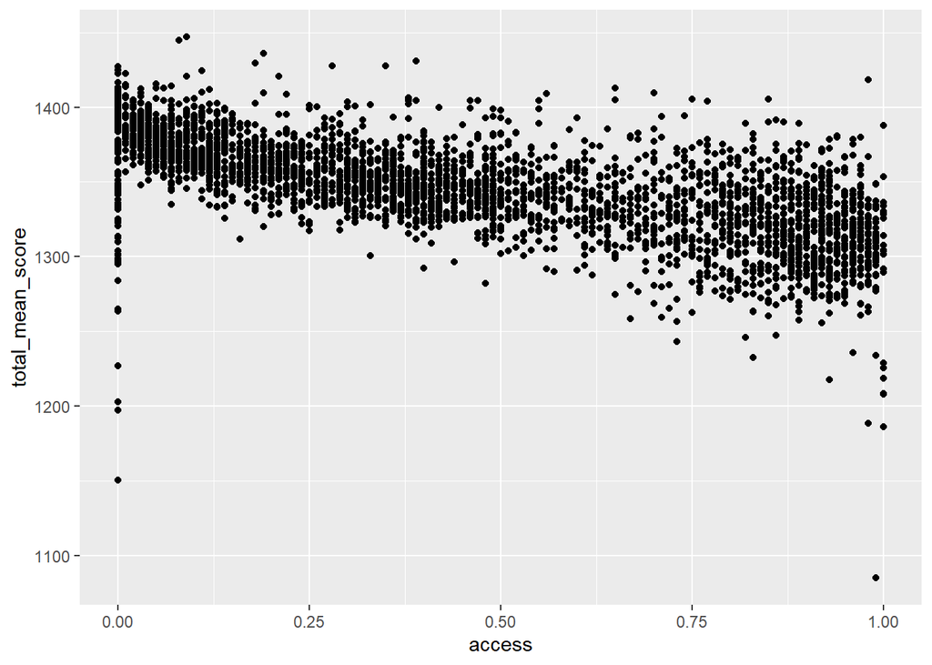

```r
plt1 %>% ggplot() +
  geom_point(aes(x=access,y = total_mean_score))
```

```r
plt2 <- new_school %>%
  filter(year == 2009) %>%
  group_by(school_name) %>%
  summarise(access = per_free_lunch+per_reduced_lunch,
            total_mean_score = mean_ela_score+mean_math_score)
```

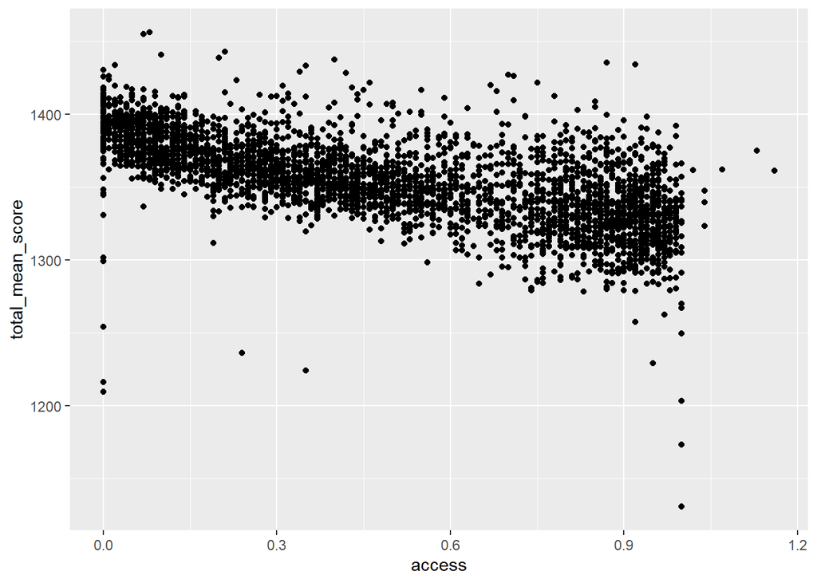

```r
plt2 %>% ggplot() +
  geom_point(aes(x=access,y = total_mean_score))
```

```r
plt3 <- new_school %>%
  filter(year == 2010) %>%
  group_by(school_name) %>%
  summarise(access = per_free_lunch+per_reduced_lunch,
            total_mean_score = mean_ela_score+mean_math_score)
```

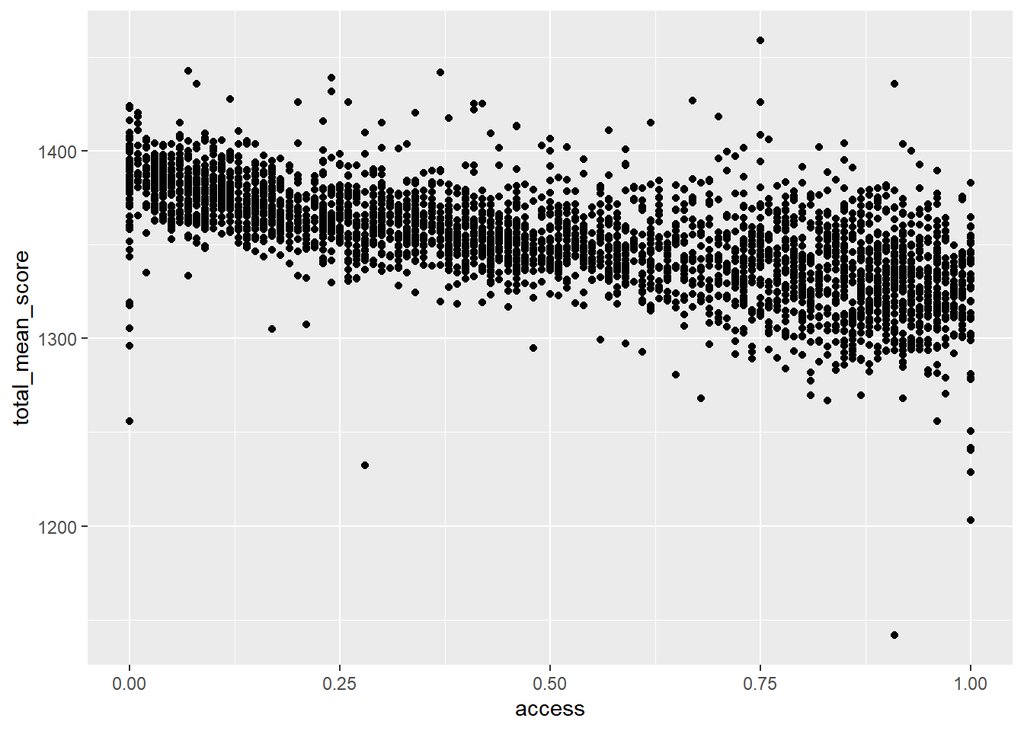

```r
plt3 %>% ggplot() +
  geom_point(aes(x=access,y = total_mean_score))
```

- By subsetting data from 2008-2010, I plotted the scatter plot of the total percentage of access to free/reduced price lunch versus the total mean scores of each school.
- Through the plot we can see a negative linear trend: for schools from which students have more access to free/reduced price lunch, these students tend to have lower total scores on both ELA and math exams.

```r
plt22 <- total_dt %>%
  group_by(group,year) %>%
  summarise(mean_score = (mean(mean_ela_score) + mean(mean_math_score))/2)
```

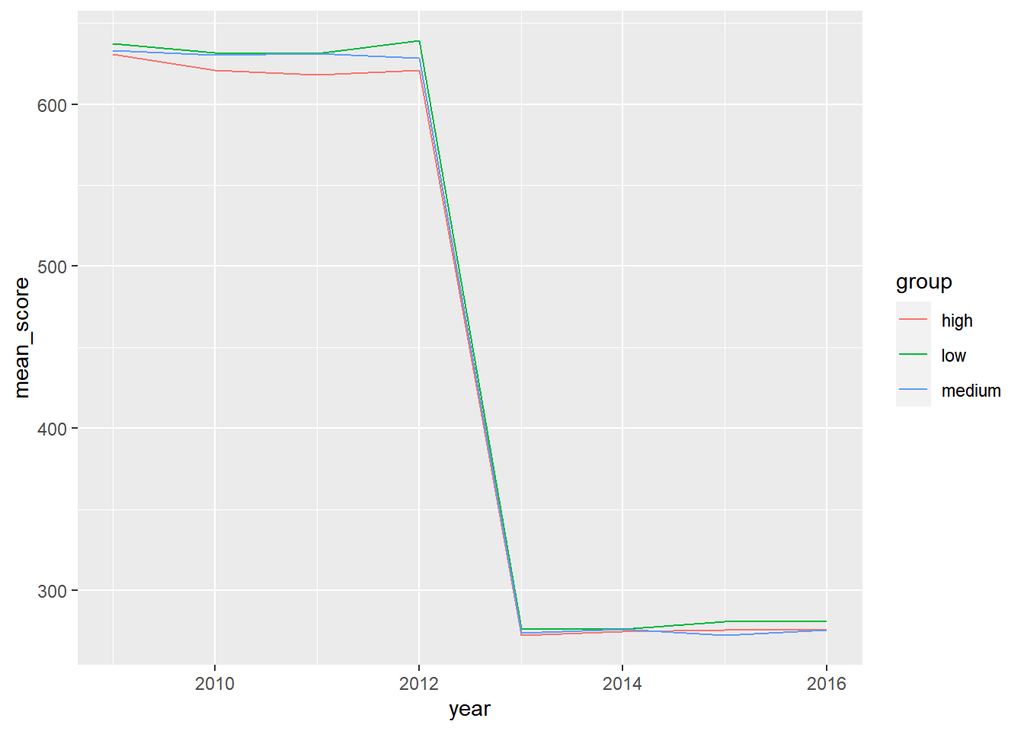

```r
plt22 <- as.data.frame(plt22)
plt22 %>% ggplot +
  geom_line(aes(x = year,y = mean_score,group = group,col = group))
```

- This plot shows the average scores of each poverty level group across the years.
- If we take averages across all counties with their group labels (high/low/medium), the differences between each group’s mean score are not as considerable.

# Task 7

```r
t7 <- total_dt %>%
  group_by(county_name) %>%
  summarise(mean_score = mean(mean_ela_score+mean_math_score),
            total_per = mean(per_free_lunch+per_reduced_lunch),
            group = group[1])
```

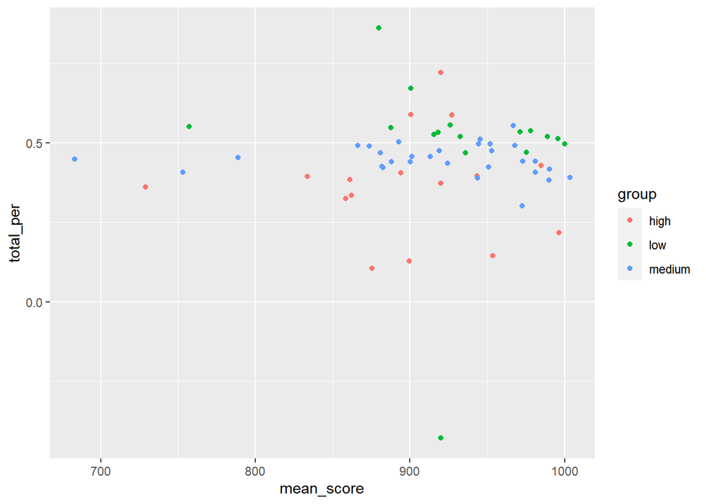

```r
t7 <- as.data.frame(t7)

t7 %>% ggplot() +
  geom_point(aes(x = mean_score,y = total_per,group = group,col = group))
```

- In the plot, each point represents a county, and the colors represent their poverty labels.
- From the plot we cannot see clear relationship between each counties poverty level(measured by the total percentage of students allowed for free/reduced price lunch) and their students’ test performances.
- However, this plot is using data that is county-level, which means that the test scores and lunch data are averaged across all schools within one county. If we go back to the plot 1 in Task 6, we do see that the schools with lowers average scores often allow more students to access free/less expensive lunch.
- Also, this trend has been consistend across the years, as illustrated by the three plots in Task 6.